# QRM II Graded Assignment (12), Period 1 2025

Material by Sjoerd van Alten and Klervie Toczé

19-09-2025

# Introduction

This assignment is to be completed in groups of 3-4. Further, all students in your group need to be assigned to the same R tutorial group (Friday’s tutorial). You can sign yourself up for a group on Canvas. Please do so You can use the Discussion Board in Canvas if you do not have a group yet or if your group is incomplete.

The assignment has 5 parts, and each part corresponds to the course material of that week (with the exclusion of week 6, for which there is no R programming material).

You are supposed to hand in these assignments on Canvas at the following dates:

- **Deadline 1** *Thursday September 25th, at 23:59pm*: you are supposed to hand in weeks 1, 2, and 3 of this assignment. This will determine 18% of your overall course grade
- **Deadline 2** *Thursday October 9th, at 23:59pm*: you are supposed to hand in weeks 4, and 5 of this assignment. This will determine 12% of your overall course grade

The R tutorials (each Friday) will consist of two halves. During the first half, you will discuss the tutorial exercises. These can be downloaded separately from Canvas. During the second half, you can work on this graded assignment within your own group. The purpose is that you find out how to work with R for doing statistical analyses by yourself. The tutorial exercises are meant to teach you basic commands to get you started, but to answer the problem sets in this assignment, you might need to research your own solutions, and use functions and commands not described in the tutorial exercises. Learning how to solve your own research problems is integral part of learning R. When you and your group get stuck on how to approach an exercise, the hierarchy in finding your way is as follows:

- use the concepts from the tutorial exercises;
- use the cheat sheets available on Canvas;
- use Google, YouTube, StackOverflow, or another website;
- ask the teacher.

The use of generative AI is permitted and may result in a grade of 0. See the AI protocol in the course manual for details.

To answer the assignment, you can simply fill out this R markdown document. There are designated places which you can fill with R code. There are also designated spaces for you to answer each question. Often, the structure of an answer will be as follows. First, you type the R code in the designated box. This will show how you analyzed the data to get the answer to the question. Below the box for the R code, you will then summarize your answer to the question, i.e. what are the conclusions that you draw from the data analysis?

When handing in, you are supposed to submit this .Rmd file, and a knitted version of this document. You can knit this document to pdf, word, or html. Knitting to pdf requires you to have a .tex distribution installed on your computer. Knitting to Word requires you to have Word installed.

The exercises are designed such that you should be able to finish the majority of them during the tutorial each week. If you are not able to finish them fully during that time, you are expected to work on it in your own time using the computers on campus or your own device. It is best to meet as a group in-person when working together. If you want to work remotely, github is a good platform to guarantee smooth collaboration. Alternatively, you can email this .Rmd file back and forth to one another as a group, but this is not recommended as it is more cumbersome.

We encourage you to keep your code blocks, printing statements, and final answers, as short as possible. In any case, there is a page limit of 6 pages per week, which encompasses the total length of this document which consists of the questions, your coding lines, and your answers. When your answers to questions of the respective week exceed this page limit, they will not be graded, resulting in zero points.

Each week consists of 1, 2, or 3 subquestions. The total amount of points you can earn per week is 20 points.

# Week 1

1. Find the dataset “movies4.tsv” on Canvas. Describe your data set: How many observations does it have. How many variables are there? How many subjects? What consists of a subject?

```r
setwd("C:/Users/basvw/OneDrive/Quantative Research Methods/R group assignment/R-Assignment-61")

library(readr)
library(tidyverse)
Movies_4 <- read_tsv("movies4.tsv")
```

**Your Answer:** This data has information about movies and includes 808 observations and 19 variables. Subjects in this data set are each individual movies and there are 808 subjects. A single subject has all the information related to one movie like budget, language, title etc.

2. Which of the following types of variables are present in your data set? (i) nominal; (ii) ordinal; (iii); interval; (iv) ratio. If present, name one example of such a variable present in your data set.

```r
#No code needed for this Question
```

**Your Answer:** In this data set we can find all previously mentioned variables. A nominal variable i.e would be genre, title, original language without any special order. Furthermore ratio variables can be found from the data set i.e budget & revenue. Ordinal variables like release month and release day. Finally, interval variables like release year.

3. A movie studio wants to know which types of movies are best at generating profit. The measure they use for this is the profitability ratio, which is defined as
   $$PR=\frac{Revenue}{Budget}.$$
   Perform the following steps to provide the movie studio with an analysis which corresponds to their request:
1. Create the variable PR as the revenue of a movie divided by its budget. Report its mean, median, maximum, and minimum.
2. As you can probably see from your answer in a.), some movies have a PR of “Inf”. What does this mean? Why are some movies assigned this value?
3. As you can probably see from your answer in a.), some movies have a PR of “NA”. What does this mean? Why are some movies assigned this value?
4. For the movies that have a PR of “Inf”, set its PR to “NA”. After doing this, report the mean, median, maximum, and minimum of PR. How do you interpret the mean?
5. What does a PR of at least one mean? What is the fraction of movies that have a PR of at least one?
6. Create a boxplot of the variable PR. Make sure it has an appropriate title, and appropriate titles and labels for the x- and y-axis. Describe the shape of the boxplot. Give $Q_1$, $Q_2$, $Q_3$ and $Q_4$. What does this tell you about the nature of making money in the movies industry?

For each step, you should provide first all the code you used to answer the question and then formulate an answer using full sentences.

*Step a*

```r
Movies_4 <- Movies_4 %>%
  mutate(PR = ifelse(budget > 0, revenue / budget, NaN))

Movies_4 %>%
  summarise(
    Mean_PR = mean(PR, na.rm = T),
    Median_PR = median(PR, na.rm = T),
    Max_PR = max(PR, na.rm = T),
    Min_PR = min(PR, na.rm = T))
```

| Mean_PR | Median_PR | Max_PR | Min_PR |
| --- | --- | --- | --- |
| 2.864599 | 1.535826 | 73.67146 | 0 |

```r
#question a without the inf. correction:
#Movies_4 <- Movies_4 %>%
#  mutate(PR = revenue / budget)
#Movies_4 %>%
#  summarise(
#    Mean_PR = mean(PR, na.rm = T),
#    Median_PR = median(PR, na.rm = T),
#    Max_PR = max(PR, na.rm = T),
#    Min_PR = min(PR, na.rm = T))
```

**Your Answer:** Mean = 2.864599 Median = 1.535826 Max = 73.67146 Minimum = 0

**without Inf. removal:** Mean = Inf Median = 1.70 Max = Inf Minimum = 0

*Step b*

```r
#No code needed for this Question
```

**Your Answer:**

Some answers have an outcome of “inf” because of a divide by zero error. Some movies have a budget of 0 which causes the PR ratio to be infinite. We encountered this problem already in answer A, and our solution to combat this problem was to write an “ifelse” function that will only formulate an answer when the budget is greater than 0. Otherwise it returns NaN. We than said to remove the NA values

*Step c*

```r
#No code needed for this question
```

**Your Answer:**

There are multiple possible reasons for there to return NA. The first is as discussed in b, we assigned that value to observations with a budget of 0. But if we look at the code without the “ifelse” function we see that PR give a NaN value when both revenue and budget are 0

*Step d*

```r
Movies_4 <- Movies_4 %>%
  mutate(PR = ifelse(budget > 0, revenue / budget, NaN))

Movies_4 %>%
  summarise(
    Mean_PR = mean(PR, na.rm = T),
    Median_PR = median(PR, na.rm = T),
    Max_PR = max(PR, na.rm = T),
    Min_PR = min(PR, na.rm = T))
```

| Mean_PR | Median_PR | Max_PR | Min_PR |
| --- | --- | --- | --- |
| 2.864599 | 1.535826 | 73.67146 | 0 |

**Your Answer:** The mean is equal to 2.864599 The median is equal to 1.535826 The maximum is equal to 73.67146 The minimum is equal to 0

The way to interpret this mean is by being aware of the difference in assigned  
weight. The way we did it was by taking the average of all movies where each has the same weight. If we took scale into consideration with the function: **PriBud_tot = sum(Movies_4**$revenue, na.rm = T) / sum(Movies_4$budget, na.rm = T) Than the mean would be lower “(2.772)” because movies with a larger budget have a lower PR ratio.

*Step e*

```r
Movies_4 %>%
  summarise(
  Frac1 = sum(Movies_4$PR >= 1, na.rm = T) / nrow(Movies_4))
```

| Frac1 |
| --- |
| 0.4566832 |

**Your Answer:**

A PR ratio of at least 1 means that the movie broke even, or made a profit. A fraction of 0.4566832 movies have a PR of 1 or higher

*Step f*

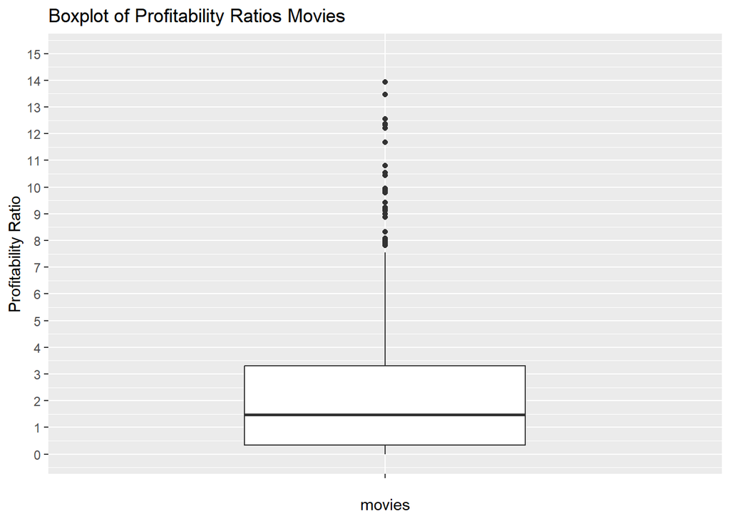

```r
ggplot(Movies_4, aes(x = " ", y = PR)) +
  geom_boxplot(width = 0.5) +
  scale_y_continuous(n.breaks = 15, limits = c(0, 15)) +
  labs(
    x = "movies",
    y = "Profitability Ratio",
    title = "Boxplot of Profitability Ratios Movies")
```

# Week 2

1 Is your dataset movies4.tsv the full population, or is it a sample of a larger population? If the latter, how would you describe the full population?

**Your Answer** The data set Movies_4 is not the full population but rather a sample. It contains 808 movies which is fewer than the total number of movies ever released. As a result, the whole population would include all movies which fit the dataset’s intended period, such as all films released worldwide (or all films in the original source database) throughout the relevant years.

2 Let M be the event that a movie director is male. Let R be the runtime of the movie.

1. Using your data, calculate $P(M)$. What is $P(M')$?. Calculate $P(M')$ as well.
2. Assume R is normally distributed with $\mu=107$ and $\sigma=22$, calculate $P(90 \leq R \leq 120)$.
3. Calculate $P(90 \leq R \leq 120)$ empirically using your data. How accurate were the assumptions about the distribution of R in 2b? Which of the assumptions do you consider the most suspect? Explain.
4. Using your data, calculate $P(120 \leq R | M')$

*step a*

```r
Prob_M <- mean(Movies_4$director_gender == "male", na.rm = T)
Prob_F <- mean(Movies_4$director_gender != "male", na.rm = T)
```

**Your Answer:** P(M)=0.895=89.5% P(M’)=0.105=10.5%

*step b*

```r
pnorm(120, 107, 22) - pnorm(90, 107, 22)
```

```
## [1] 0.5028674
```

**Your Answer:** P(90 ≤ R ≤ 120) = 0.503

*step c*

```r
#Probability question 2B = 0.5028674
Movies_4 %>%
  summarise(
    Prob_R = mean(runtime >= 90 & runtime <= 120 , na.rm = T),
    Mean_run = mean(runtime, na.rm = T),
    SD_RUN = sqrt(var(runtime, na.rm = T)))
```

| Prob_R | Mean_run | SD_RUN |
| --- | --- | --- |
| 0.6571782 | 105.3936 | 20.62616 |

**Your Answer:** Our mean is 105.3 which is very close to the assumed mean of 107. The standard deviation came out as 20.6 which is decently close to the assumed 22, so the standard deviation would be the most suspect out of the two.

*step d*

```r
#Filter for female movies
F_Movies_4 <- Movies_4 %>%
  filter(director_gender != "male")

#Proportion R >= 120
F_Movies_4 %>%
  summarise(
    F_P_R = mean(runtime >= 120, na.rm = T))
```

| F_P_R |
| --- |
| 0.1875 |

**Your Answer:** P(120 ≤ R|M ′) = 0.1875=19%

3 For this question, you will again use the profitability ratio PR. Make sure that PR is defined the same way as in question 3d of week 1. For this question, you will assume that your data set is the full population.

1. What is the mean of the variable PR in your data set?
2. Create a new data set, called movies_sample. Make sure that it is a random sample of your data set of 25 movies. What is the mean of PR in this random sample? How does it compare to the mean of PR in 3a?
3. In a for loop, create 100 different samples of 25 movies, as in b, and estimate the mean within each sample. Save the mean of each sample in a vector called sample_means. So the first position of the vector would have the mean of the first sample, the second position the mean of the second sample, etc. Print this vector.
4. Summarize and make a histogram of sample_means. What is the mean, standard deviation and shape of its distribution?
5. Using the formulas of the *Central Limit Theorem*, give the distribution of the sample mean of PR in a sample of 25 movies from you population (including its expected value and standard deviation). How do these values compare to your answers at d.)?

*step a*

```r
Movies_4 %>%
    summarise(Mean_PR = mean(PR, na.rm = T))
```

| Mean_PR |
| --- |
| 2.864599 |

**Your Answer:** Mean(PR) = 2.864599

*step b*

```r
Movies_sample = Movies_4[sample(nrow(Movies_4),25, replace = F),]

Movies_sample %>%
    summarise(Mean_S_PR = mean(PR, na.rm = T))
```

| Mean_S_PR |
| --- |
| 2.716828 |

*step c*

```r
set.seed(837)
sample_means <- c()

for (i in c(1:100))
  {Movies_sample2 = Movies_4[sample(nrow(Movies_4),25, replace = F),];       sample_means[i] <- mean(Movies_sample2$PR, na.rm = T)}
```

*step d*

```r
DF_sample_means <- data.frame(sample_means)

DF_sample_means %>%
  summarise(
    Mean_sam = mean(sample_means, na.rm = T),
    SD_sam = sqrt(var(sample_means, na.rm = T)))
```

| Mean_sam | SD_sam |
| --- | --- |
| 2.889988 | 1.145964 |

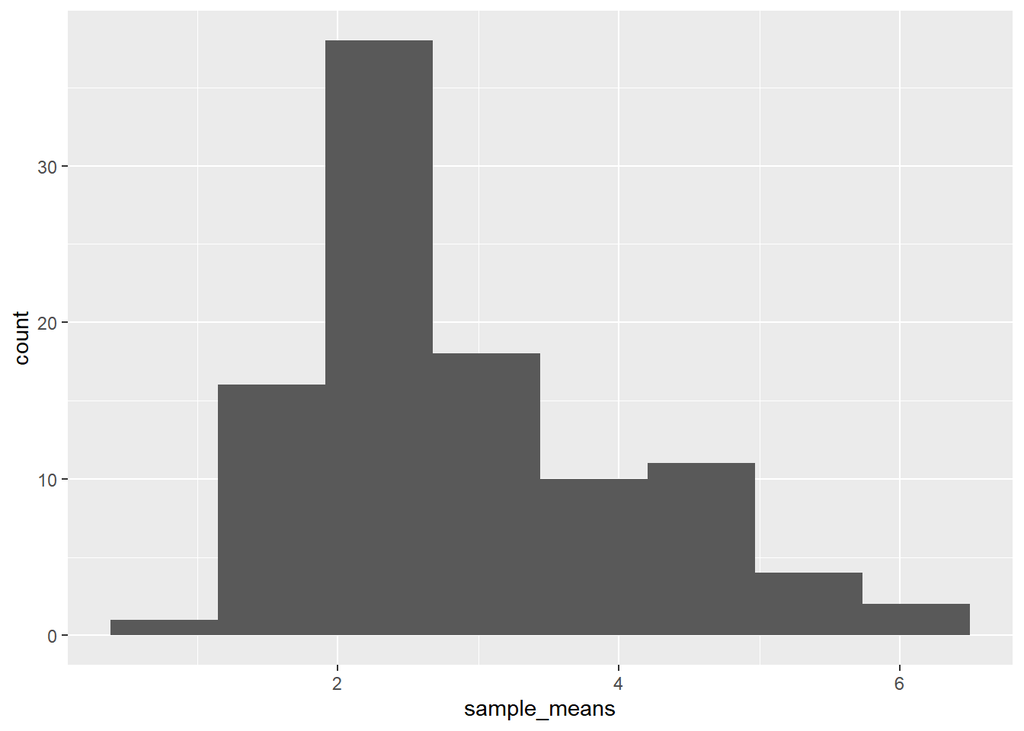

```r
ggplot(DF_sample_means, aes(x = sample_means)) +
  geom_histogram(bins = 8)
```

**Your Answer:** Our PR mean of our sample mean is 2.89. Which is very close to the mean PR of our original data set of 2.864. And our SD is 1.146. Our histogram is skewed right with outliers.

*step e* **Your Answer:** the original population mean is 2.864 and the standard deviation is 5.43 [Movies_4 %>% summarise( Mean_PR = mean(PR, na.rm = T), SD_RUN = sqrt(var(PR, na.rm = T)))] the expected value of the sample mean is equal to the mean of the population so E(mean) = 2.864 which is very similar to our answer of 2.89 in question d

the standard deviation of the mean will be the standard deviation of the original population divided by sqrt(n) (sample size) = sqrt(25) 5.43 / 5 = 1.086 this is also close to our answer of 1.146 in question d